# R Notebook

This is part of the same process as A1.4 for we stored the data before hypothesis testing.

```r
## ---- load-a1-objects ----

obj <- readRDS("data/d1_qc_objects.rds")

dge  <- obj$dge_filtered
meta <- obj$meta
mappings <- obj$mappings
```

Recreate design matrix

```r
## ---- recreate-design ----

meta$timepoint <- factor(meta$timepoint)
meta$treatment <- factor(meta$treatment, levels = c("CTL", "PAL"))

design <- model.matrix(~ timepoint + treatment, data = meta)

colnames(design)
```

```
[1] "(Intercept)"  "timepoint18h" "timepoint24h"
[4] "timepoint30h" "timepoint36h" "timepoint42h"
[7] "timepoint48h" "timepoint54h" "treatmentPAL"
```

Re-estimate dispersion and fit QL model

```r
## ---- fit-edger-model ----

dge <- estimateDisp(dge, design)

fit <- glmQLFit(dge, design)
```

Verify if its working as before:

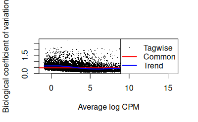

```r
plotBCV(dge)
```

Hypoothesis testing

```r
## ---- ql-test ----

qlf_pal_vs_ctl <- glmQLFTest(
  fit,
  coef = "treatmentPAL"
)

res_pal <- topTags(qlf_pal_vs_ctl, n = Inf)$table %>%
  tibble::rownames_to_column("ensembl")
```

Verify same number as before:

```r
sum(res_pal$PValue < 0.05)
```

[output not shown]

```r
sig_res <- res_pal %>%
  filter(FDR < 0.05, abs(logFC) >= 1)

nrow(sig_res)
```

Split into up and down:

```r
sig_up <- sig_res %>% filter(logFC > 0)
sig_down <- sig_res %>% filter(logFC < 0)

nrow(sig_up)
nrow(sig_down)
```

1.1 Method Choice Method: Thresholded Over-Representation Analysis (ORA)

We use:

g:Profiler (gprofiler2 R package)

Hypergeometric test

Benjamini–Hochberg FDR correction

Why this method?

We already defined significant genes using FDR < 0.05 and |logFC| ≥ 1.

ORA is appropriate when using a pre-thresholded gene list.

It tests whether gene sets are enriched beyond random expectation.

We use g:Profiler built-in annotation sources:

```r
gprofsources = c("GO:BP", "REAC", "WP")
```

Annotation version

Inspect gene lists

Extract the Gene list by unique ensembl or biomart symbel.

```r
genes_up   <- unique(sig_up$ensembl)
genes_down <- unique(sig_down$ensembl)
genes_all  <- unique(sig_res$ensembl)

length(genes_up)
length(genes_down)
```

Run Upregulated

```r
gost_up <- gost(
  query = genes_up,
  organism = "hsapiens",
  significant = FALSE,
  ordered_query = FALSE,
  exclude_iea = TRUE,
  correction_method = "fdr",
  sources = gprofsources
)

res_up <- gost_up$result
```

Run Downregulated

```r
gost_down <- gost(
  query = genes_down,
  organism = "hsapiens",
  significant = FALSE,
  ordered_query = FALSE,
  exclude_iea = TRUE,
  correction_method = "fdr",
  sources = gprofsources
)

res_down <- gost_down$result
```

Combined

```r
gost_all <- gost(
  query = genes_all,
  organism = "hsapiens",
  significant = FALSE,
  ordered_query = FALSE,
  exclude_iea = TRUE,
  correction_method = "fdr",
  sources = gprofsources
)

res_all <- gost_all$result
```

We performed thresholded over-representation analysis (ORA) using the gprofiler2::gost() function with the following parameters:

query = genes_up / genes_down / genes_all

The query represents the list of significantly differentially expressed genes identified from edgeR analysis (FDR < 0.05 and |log2FC| ≥ 1). Up-regulated, down-regulated, and combined gene sets were analyzed separately to preserve biological directionality.

organism = “hsapiens”

The organism parameter specifies that Homo sapiens annotation databases were used for enrichment analysis.

significant = FALSE

We set significant = FALSE to retrieve all enrichment results rather than restricting output to only those passing g:Profiler’s internal significance threshold. This allows us to apply our own filtering criteria downstream.

ordered_query = FALSE

Because this analysis is thresholded ORA (not ranked GSEA), genes were treated as an unranked set. Therefore, ordered_query = FALSE was appropriate.

exclude_iea = TRUE

Inferred Electronic Annotations (IEA) were excluded to increase annotation reliability by limiting enrichment to manually curated or experimentally supported terms.

correction_method = “fdr”

Multiple hypothesis correction was performed using the Benjamini–Hochberg False Discovery Rate (FDR) method to control for false positives across many tested gene sets.

sources = gprofsources

The following annotation databases were included:

GO:BP (Biological Process)

REAC (Reactome pathways)

WP (WikiPathways)

Analysis:

The orginal paper applies RAIN algorithm for seperating cirardian genes from other effected genes as lipid intake alters well studied pathway such as lipid intake. Here we see if a bulk enrichment non theresholded ora can identify cirardian genes alone with lipid intake.

1. Identify the biological expectation from the paper

From the paragraph:

“Palmitate-responsive genes were associated with gene ontology pathways related to lipid metabolism (Figure 1E).”

So the expected pathways include things like:

Typical lipid-related GO BP terms:

lipid metabolic process

fatty acid metabolic process

fatty acid beta oxidation

lipid biosynthetic process

sterol metabolic process

lipid transport

These become your benchmark.

If ORA finds these → result is relevant.

```r
classify_theme <- function(df) {
  df %>%
    mutate(
      theme = case_when(
        str_detect(term_name, regex("circadian|clock|rhythm", ignore_case = TRUE)) ~ "Circadian",
        str_detect(term_name, regex("lipid|fatty|cholesterol|sterol|acyl", ignore_case = TRUE)) ~ "Lipid metabolism",
        TRUE ~ "Other"
      )
    )
}
```

```r
res_up_theme   <- classify_theme(res_up)
res_all_theme  <- classify_theme(res_all)
```

```r
count_theme <- function(df, label) {
  df %>%
    group_by(theme) %>%
    summarise(count = n(), .groups = "drop") %>%
    mutate(group = label)
}

summary_up   <- count_theme(res_up_theme, "Upregulated")
summary_all  <- count_theme(res_all_theme, "All")
```

```r
threshold_summary <- bind_rows(
  summary_up,
  summary_all
)

themes <- c("Lipid metabolism", "Circadian", "Other")
groups <- c("Upregulated", "Downregulated", "All")

threshold_summary <- threshold_summary %>%
  complete(group = groups, theme = themes, fill = list(count = 0))
```

```r
library(ggplot2)

ggplot(threshold_summary, aes(x = group, y = count, fill = theme)) +
  geom_bar(stat = "identity", position = "dodge") +
  theme_minimal() +
  labs(
    title = "Enriched genesets by biological theme (Thresholded ORA)",
    x = "Gene set",
    y = "Number of genesets",
    fill = "Theme"
  )
```

[output not shown]

```r
get_top_terms <- function(df, group_name) {
  df %>%
    group_by(theme) %>%
    slice_min(p_value, n = 1, with_ties = FALSE) %>%
    ungroup() %>%
    select(theme, top_term = term_name, p_value) %>%
    mutate(group = group_name)
}

top_up  <- get_top_terms(res_up_theme, "Upregulated")
top_all <- get_top_terms(res_all_theme, "All")

top_terms <- bind_rows(top_up, top_all)

themes <- c("Lipid metabolism", "Circadian", "Other")
groups <- c("Upregulated", "Downregulated", "All")

top_terms <- top_terms %>%
  complete(group = groups, theme = themes,
           fill = list(top_term = NA, p_value = NA))

threshold_summary_table <- threshold_summary %>%
  left_join(top_terms, by = c("group", "theme"))

knitr::kable(
  threshold_summary_table,
  caption = "Summary of enriched pathways by biological theme with top representative term"
)
```

[output not shown]

Size filtered Results reusing similar code

```r
min_gs_size <- 3
max_gs_size <- 250
min_intersection <- 2

res_up_f <- subset(res_up,
                   term_size >= min_gs_size &
                   term_size <= max_gs_size &
                   intersection_size >= min_intersection)

res_all_f <- subset(res_all,
                    term_size >= min_gs_size &
                    term_size <= max_gs_size &
                    intersection_size >= min_intersection)

classify_theme <- function(df) {
  df %>%
    mutate(
      theme = case_when(
        str_detect(term_name, regex("circadian|clock|rhythm", ignore_case = TRUE)) ~ "Circadian",
        str_detect(term_name, regex("lipid|fatty|cholesterol|sterol|acyl", ignore_case = TRUE)) ~ "Lipid metabolism",
        TRUE ~ "Other"
      )
    )
}

res_up_f_theme  <- classify_theme(res_up_f)
res_all_f_theme <- classify_theme(res_all_f)

count_theme <- function(df, label) {
  df %>%
    group_by(theme) %>%
    summarise(count = n(), .groups = "drop") %>%
    mutate(group = label)
}

summary_up_f  <- count_theme(res_up_f_theme, "Upregulated")
summary_all_f <- count_theme(res_all_f_theme, "All")

filtered_summary <- bind_rows(summary_up_f, summary_all_f)

get_top_terms <- function(df, group_name) {
  df %>%
    group_by(theme) %>%
    slice_min(p_value, n = 1, with_ties = FALSE) %>%
    ungroup() %>%
    select(theme, top_term = term_name, p_value) %>%
    mutate(group = group_name)
}

top_up_f  <- get_top_terms(res_up_f_theme, "Upregulated")
top_all_f <- get_top_terms(res_all_f_theme, "All")

top_terms_f <- bind_rows(top_up_f, top_all_f)

themes <- c("Lipid metabolism", "Circadian", "Other")
groups <- c("Upregulated", "All")

filtered_summary <- filtered_summary %>%
  complete(group = groups, theme = themes, fill = list(count = 0))

top_terms_f <- top_terms_f %>%
  complete(group = groups, theme = themes,
           fill = list(top_term = NA, p_value = NA))

filtered_summary_table <- filtered_summary %>%
  left_join(top_terms_f, by = c("group", "theme"))

knitr::kable(
  filtered_summary_table,
  caption = "Filtered ORA pathway summary with representative term per biological theme"
)
```

[output not shown]

Part 2 Unthrreshold set output location:

```r
working_dir <- "./data"
```

create ranked gene list

```r
library(dplyr)

# Create ranked table
res_rank <- res_pal %>%
  mutate(rank_score = sign(logFC) * -log10(PValue)) %>%
  arrange(desc(rank_score))

# Keep only required columns
rnk_df <- res_rank %>%
  select(ensembl, rank_score)

# Define file path
working_dir <- "./data"
dir.create(working_dir, showWarnings = FALSE)

rnk_file <- "PAL_vs_CTL_ranked.rnk"
rnk_path <- file.path(working_dir, rnk_file)

# Write .rnk file
write.table(
  rnk_df,
  file = rnk_path,
  sep = "\t",
  row.names = FALSE,
  col.names = FALSE,
  quote = FALSE
)
```

Download fixed version fir GMT from baderlab

```r
library(RCurl)

output_dir <- "./generated_data/gsea"
dir.create(output_dir, recursive = TRUE, showWarnings = FALSE)

gmt_url  <- "https://download.baderlab.org/EM_Genesets/September_01_2025/Human/symbol/Human_GOBP_AllPathways_noPFOCR_no_GO_iea_September_01_2025_symbol.gmt"

gmt_file <- "Human_GOBP_AllPathways_noPFOCR_no_GO_iea_September_01_2025_symbol.gmt"
gmt_path <- file.path(output_dir, gmt_file)

if (!file.exists(gmt_path)) {
  download.file(gmt_url, destfile = gmt_path, mode = "wb")
}
```

September 01, 2025 GO BP + Pathways No IEA Human symbols

Configure GSEA CLI

```r
gsea_jar <- path.expand("~/GSEA_4.4.0/gsea-cli.sh")
```

Run:

```r
analysis_name <- "PAL_vs_CTL"

gsea_stdout <- file.path(output_dir, "gsea_output.txt")

command <- paste(
  shQuote(gsea_jar),
  "GSEAPreRanked",
  "-gmx", shQuote(gmt_path),
  "-rnk", shQuote(rnk_path),
  "-collapse false",
  "-nperm 1000",
  "-scoring_scheme weighted",
  "-rpt_label", shQuote(analysis_name),
  "-plot_top_x 20",
  "-rnd_seed 12345",
  "-set_max 200",
  "-set_min 15",
  "-zip_report false",
  "-out", shQuote(output_dir),
  ">", shQuote(gsea_stdout)
)

cat("Running command:\n", command, "\n")
system(command)
```

Gene sets were restricted to sizes between 15 and 200 genes to exclude very small unstable sets and overly broad non-specific categories.

Summary of enrichment results

Among the positively enriched pathways were processes related to:

mTORC1 signaling

cholesterol biosynthesis regulation

lipid biosynthetic processes

PPAR-α regulated lipid metabolism

steroid metabolism

endoplasmic reticulum stress response

Several metabolic pathways related to mitochondrial respiration and oxidative phosphorylation were negatively enriched.

Overall, the enrichment pattern indicates that palmitate treatment strongly affects lipid metabolic pathways and cellular stress responses, which is consistent with the known lipotoxic effects of saturated fatty acids.

The non-thresholded GSEA analysis provides a complementary perspective because it considers all genes ranked by differential expression rather than only a subset passing significance thresholds.

Compared with the thresholded ORA:

GSEA identified stronger enrichment of coordinated metabolic pathways

Lipid metabolism and cholesterol biosynthesis pathways were clearly detected

Additional metabolic stress pathways such as ER stress and mTOR signaling were also revealed

However, circadian pathways remained weakly enriched even in the non-thresholded analysis.

Therefore, while both approaches highlight metabolic responses to palmitate, GSEA captures broader coordinated pathway signals that may be missed by thresholded ORA.

Is this a straightforward comparison?

The comparison between thresholded ORA and non-thresholded GSEA is not entirely straightforward, because the two methods rely on fundamentally different assumptions.

ORA tests whether a selected list of significant genes is over-represented in known pathways, which depends heavily on the chosen significance threshold.

In contrast, GSEA evaluates whether genes belonging to a pathway tend to appear toward the top or bottom of the ranked gene list, allowing detection of subtle but coordinated expression changes across many genes.

As a result, GSEA can identify biologically meaningful pathways even when individual genes do not pass strict differential expression thresholds.

Thus, while both analyses point toward lipid metabolism as the dominant biological response to palmitate, GSEA provides a more comprehensive view of coordinated pathway regulation.